# Relatório 02

Gustavo Duque Thomaz Mourão Elias

27/04/2022

# 1 Objetivo

Descrever o processo de pordução do relatório das aulas da disciplina, abordando os seguintes passos:

- Instalação do Git e cadastro do GitHub;
- Criação do repositório e clonagem dele à máquina local;
- Instação dos pacotes `markdown`, `knitr`, `tinytex` e `postcard`;
- Básico do RMarkdown;
- “Comitando” mudanças e “empurrando” dados ao repositório do GitHub;
- Criando uma página online do repositório;

# 2 Apresentação do relatório

Dado o objetivo do relatório, os pontos feitos anteriormente serão abordados nos subtópicos:

## 2.1 Instalação do Git e cadastro no GitHub

### 2.1.1 Sobre

O programa Git tem como função rastrear mundanças em arquivos, permitindo sincronização de dados online[^1]. O GitHub, por sua vez, é a plataforma online para controle, armazenamento e distribuição para os dados que são passados pelo Git.

Por causa de sua natureza colaborativa e aberta, o site é um ambiente ideal para desenvolvimento de códigos e programação e, por causa fator e outros motivos, foi escolhido como o local de arquivamento e apresentação dos relatórios

### 2.1.2 Instalação do Git

O link para instalação nos três principais sistemas operacionais no mercado (Windows, MacOS e Linux) pode ser encontrado aqui: https://git-scm.com/downloads.

### 2.1.3 Criação de conta no GitHub

Para criar uma conta no GitHub, acesse https://github.com/signup?source=login.

## 2.2 Criação do repositório e clonagem dele à máquina local

Para o processo de clonagem de um repositório feito no GitHub, sigua os seguintes passos

- Para uso do terminal Git no RStudio, vá na barra de ferramentas acima e clique em *Tools* e vá escolhendo as abas e opções a seguir: *RStudio* > *Tools* > *Global Options…* > *Terminal* > *General* > *Shell* > *New Terminal open with*: *Git Bash* > *Apply*;

[figure not shown]

- Crie um repositório no GitHub, o qual será o repositório a ser clonado. Na página da conta pessoal. A demanda da classe, nomeio o repositório como `<usuario_conta>.github.io` ou `dicestcomp`;

[figure not shown]

- Abra o repositório no GitHub. clique no botão *Code* e copie o código HTTPS;

[figure not shown]

- Vá ao RStudio, novamente na barra de ferramentas superior, e clique em *File* e siga: *New Project…* > *Version Control* > *Git* > *Repository URL* > insira o HTTPS do repositório Git.

[figure not shown]

## 2.3 Instação dos pacotes `markdown`, `knitr`, `tinytex` e `postcard`

### 2.3.1 Instalação via console do R

Os métodos de instalação de pacote podem ser instalados pelos métodos demonstrados no Relatório 1. Além deles, há a opção de usar dois comandos para instalar os quatro pacotes simultaneamente:

```r
# declarando pkgs como a concatenação deste conjunto de pacotes

pkgs <- c("rmarkdown", "knitr", "tinytex", "postcard")

# instalando os pacotes

install.packages(pkgs)
```

### 2.3.2 Conteúdo dos pacotes

Cada pacote ajudará na produção do texto dos relatórios, sendo que cada um deles traz funções e estruturas novas possibilitando a criação dos relatórios no R:

- `rmarkdown`: possibilita o uso do Markdown no R, permitindo a criação de textos em HTML;
- `knitr`: permite a geração e visualização dos documentos em Markdown no R;
- `tinytex`: habilita a compilação de documentos em LaTex e impressão em PDF;
- `postcard`: template em Markdown para fazer um cartão de negócios online;

## 2.4 Básico do RMarkdown

### 2.4.1 Markdown

O Markdown original é uma linguagem de programação de marcação, usada para edição de texto e com a possibilidade de tradução da estrutura gerada para outros tipos de documento como HTML, Word, PDF, etc. O RMarkdown, por sua vez, é a integração desta linguagem ao RStudio, possibilitando a edição de textos dentro desta interface.

Por ser uma linguagem de marcação, o Markdown tenta se aproximar da escrita humana, conferindo-lhe praticidade e intuitividade na hora de formular textos.

### 2.4.2 Estruturas de escrita

Nesta seção, serão demonstradas comandos básicos para escrita em Markdown:

- Escrita em itálico: (`*itálico*`) *itálico*
- Escrita em negrito: (`**negrito**`) ou (`_negrito_`) **negrito**

-Nota de rodapé: `palavra^[citação]` Gustavo[^2]

- Links: `[Nome do Link](Link])` [Link](https://www.youtube.com/watch?v=dQw4w9WgXcQ)
- Imagem: `![Nome da imagem](Local da imagem){Argumentos extras}`
- Inserindo resultado de objeto no texto “r objeto” **5.5**
- Listas: `-`. Para fazer sublistas, escreva uma linha abaixo com um `tab` mais o travessão:
  - Exemplo de sublista usando esta sintaxe.
    - Mais uma sublista nesta sintaxe.

-Chunks de código: botão verde acima

```r
dados <- (0:10)
dados
```

```
##  [1]  0  1  2  3  4  5  6  7  8  9 10
```

Média: 5

- Equação:
  - Começa com a equação sendo colocada entre dois cifrões `$___$`;
  - Uso da sintaxe do Latex. Incia-se com a contra-barra `\` e depois o nome do comando. Alguns exemplos:
    - `\frac{}{}` para expressar uma fração, primeiro argumento numerador e segundo, denominador;
    - `\int{}` para integral não definida;
    - `\alpha` para deixar a letra grega alfa. Demais letras gregas pode ser invocadas mas seus nomes devem ser escritos em inglês;

  Exemplo da escrita demonstrada:

  $X^{h - \alpha} - \int{a\sqrt{\frac{a}{s}}da}$

## 2.5 “Comitando” mudanças e “empurrando” dados ao repositório do GitHub

Ao editar arquivos do repositório clonado, uma nova janela no terceiro quadrante estará disponível: a janela *Git*.

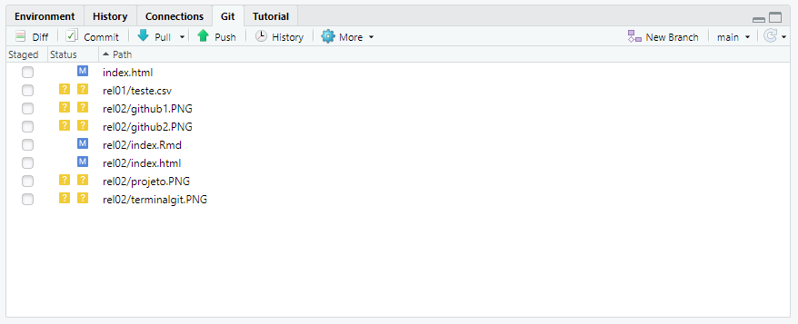

Ela indicará arquivos que foram acrescentados e modificados em relação ao reposítório. Para mandar estas mudanças ao repostitório online, deverá feito um “commit” (indicar as mudanças feitas e marcando este ponto de mudança) e “empurrar” (“push”) os dados ao repositório. Há duas maneiras de se fazer este processo: via a aba do *Git* no RStudio ou usando o terminal Git

### 2.5.1 Via aba *Git*

Na aba *Git*, clique nos “check boxes” dos arquivos os quais se deseja empurrar. Ao os selecionar, clique no botão *Commit*. Com isso abrairá uma nova aba com um quadro branco a direita.

[figure not shown]

Descreva as mudanças feitas no repositório neste quadro. Evite acentos ou caracteres como “ç” para não desconfigurar a mensagem ao exportar ao GitHub.

Feito o “commit”, clique em *Push* para enviar os dados ao repositório.

### 2.5.2 Via terminal

No RStudio, vá ao segundo quadrante e clique em *Terminal*. Insira as seguintes linhas, uma a cada vez:

```
# add é o comando de adicionar arquivos ao repositório. O ponto indica que qualque arquivo acrescentado ou modificado será enviado

$ git add .

# coloque o comentário do commit entre as aspas

$ git commit -m "comentario"

# comando para fazer o empurro

$ git push
```

## 2.6 Criando uma página online do repositório

Para que o relatório possa ser exibido como página na internet, alguns passos a mais deverá ser tomados.

Primeiramente, o arquivo do Markdown deverá ser salvo com o nome específico de `index` e o arquivo deverá ser compilado para HTML. No primeiro quadrante, clique no “drop´down” do *Knit* e escolha *Knit on HTML*

Ao chegar ao Github, vá ao repositório e clique em *Setting* e vá para a seção *Pages*.

[figure not shown]

Escolha a fonte como `main root` e salve. O site disponibilizará um link e dentro de um breve tempo, a página estará no ar.

[^1]: Fonte: [Wikipedia](https://en.wikipedia.org/wiki/Git)
[^2]: Alguém